# Analysing Sentences Cluster

Published

August 22, 2025

```r
source(here::here("scripts", "paths_and_packages.R"))
p_load(see)
p_load(kableExtra,
       DT)

# Loading Data
bert_df <- readRDS(file.path(data_path, "closest_sentences_0.01_rationality_score_with_embeddings.rds")) %>%
  arrange(sentence_id) %>%
  filter(between(publication_year, 1900, 2019))

metadata <- read_rds(file.path(data_path, "full_metadata_journals_cleaned.rds")) %>%
  .[ refined_sub_type == "research-article" & language == "eng", .(id, is_part_of, title, creator, publication_year)] %>%
  .[order(publication_year)]

documents_cluster <- readRDS(file.path(data_path, "sentences_intertemporal_cluster.rds")) %>%
  left_join(select(bert_df, id, sentence, sentence_id, similarity)) %>%
  left_join(metadata) %>%
  arrange(sentence_id)

list_clusters <- documents_cluster %>%
  mutate(rank_cluster = str_extract(new_cluster, "\\d+$") %>% as.integer()) %>%
  arrange(rank_cluster) %>%
  pull(new_cluster) %>%
  unique()
```

```r
# Naming clusters and tf-idf---------------------
setDT(documents_cluster)
unigrams <- documents_cluster[, .(sentence_id, sentence, window, new_cluster)][, token := tokenizers::tokenize_words(sentence, lowercase = TRUE)][, -("sentence")]
bigrams <- documents_cluster[, .(sentence_id, sentence, window, new_cluster)][, token := tokenizers::tokenize_ngrams(sentence, n= 2, lowercase = TRUE)][, -("sentence")]
tokens <- rbind(unigrams,
                bigrams)
tokens <- tokens[, .(token = unlist(token)), by = .(new_cluster, window)]
tokens <- tokens[nchar(token) >= 2, ]
tokens <- tokens[, c("word_1", "word_2") := tstrsplit(token, " ")]

stop_words <- tidytext::stop_words$word %>%
  unique()
tokens <- tokens[
  # Remove any digits in either word
  !grepl("[0-9]", word_1) & (is.na(word_2) | !grepl("[0-9]", word_2)) &
    # Remove stopwords in either word
    !(word_1 %in% stop_words) &
    (is.na(word_2) | !(word_2 %in% stop_words))
]
tokens <- tokens[, .(new_cluster, window, token)]
tokens[, token := str_replace(token, " ", "_")]

tokens_count_cluster <- compute_tf_idf(tokens[, -"window"],
                                       token_col = "token",
                                       document_col = "new_cluster")

# Top tf-idf terms
top_terms_cluster <- tokens_count_cluster[order(-tf_idf)][absolute_tf > 30, head(.SD, 20), by = new_cluster]

tokens[, new_variable := str_c(new_cluster, "--", window)]
tokens_count_window <- compute_tf_idf(tokens,
                                      token_col = "token",
                                      document_col = "new_variable")
# Top tf-idf terms
top_terms_window <- tokens_count_window[order(-tf_idf)][absolute_tf > 20, head(.SD, 15), by = new_variable]

# Get top 4 tf-idf tokens per cluster
labels_cluster <- tokens_count_cluster[order(-tf_idf)][absolute_tf > 30, head(.SD, 5), by = new_cluster][, .(new_cluster, token)]
labels_cluster <- labels_cluster[, .(label = paste0(token, collapse = ", ")), by = new_cluster]
labels_cluster[, label := paste0(str_extract(new_cluster, "\\d+$"), ": ", label)]

documents_cluster <- merge(documents_cluster, labels_cluster, all.x = TRUE, by = "new_cluster")

# Labels per decade
labels_window<- tokens_count_window[order(-tf_idf)][absolute_tf > 20, head(.SD, 5), by = new_variable][, .(new_variable, token)]
labels_window <- labels_window[, .(label = paste0(token, collapse = ", ")), by = new_variable]
labels_window[, label := paste0(str_extract(new_variable, "\\d+(?=--)"), ": ", label)]
```

```r
palette_colors <- c(see::see_colors(),
                    see::oi_colors()[1:7],
                    scico::scico(n = 8, palette = "roma"),
                    scico::scico(n = 8, palette = "tokyo"),
                    scico::scico(n = 8, palette = "hawaii"),
                    scico::scico(n = 8, palette = "batlowK"),
                    scico::scico(n = 7, palette = "bamako"),
                    scico::scico(n = 7, palette = "glasgow")) %>%
  sample()

nb_clusters <- documents_cluster %>%
  pull(new_cluster) %>%
  unique() %>%
  length
if(nb_clusters > length(palette_colors)) message("no sufficient colors")
cluster_colors <- palette_colors[1:nb_clusters]
names(cluster_colors) <- documents_cluster$new_cluster %>%
  unique
```

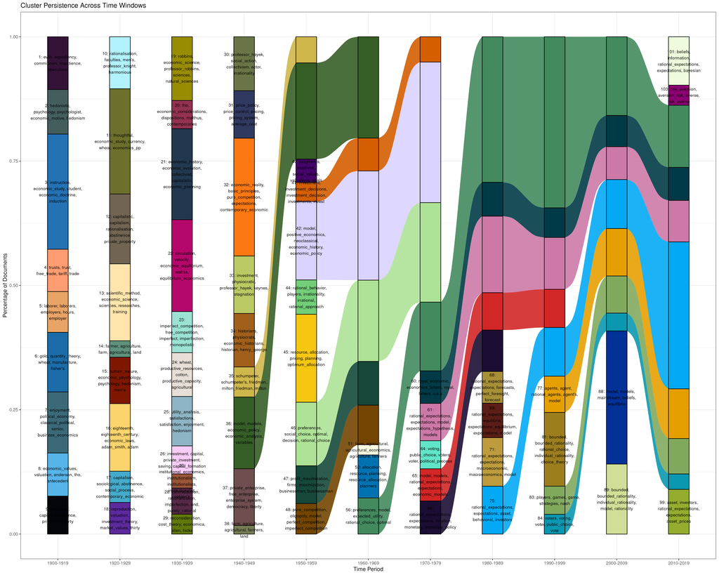

```r
label_alluvial_position <- documents_cluster %>%
  distinct(new_cluster, label, window) %>%
  mutate(first_year = str_extract(window, "\\d{4}") %>% as.integer()) %>%
  mutate(label_alluvial = first_year == min(first_year), .by = label) %>%
  filter(label_alluvial == TRUE) %>%
  mutate(label_alluvial = label) %>%
  distinct(new_cluster, label_alluvial, window)

alluvial <- documents_cluster %>%
  count(window, new_cluster, label) %>%
  left_join(label_alluvial_position) %>%
  mutate(percent = n / sum(n), .by = window) %>%
  #  mutate(new_cluster = factor(new_cluster, levels= all_clusters)) %>%
  ggplot(aes(x = window, y = percent, stratum = new_cluster, alluvium = new_cluster,
             fill = new_cluster)) +
  geom_flow(alpha = 0.9) +
  geom_stratum() +
  geom_text(aes(label = str_wrap(label_alluvial, 25)), stat = "stratum", size = 3) +
  labs(title = "Cluster Persistence Across Time Windows",
       x = "Time Period",
       y = "Percentage of Documents",
       fill = "Intertemporal Cluster") +
  theme_bw() +
  theme(legend.position = "none") +
  scale_fill_manual(values = cluster_colors)  # HARD color lock

ggsave(here("pictures", "intertemporal_clusters_alluvial.png"),
       alluvial,
       units = "cm",
       width = 50,
       height = 40,
       dpi = 300)

knitr::include_graphics(here("pictures", "intertemporal_clusters_alluvial.png"))
```

```r
# Top sentences----------------------------------
# Build embedding matrix

# Convert to data.table
bert_df <- merge(bert_df,
                 select(documents_cluster, sentence_id, window, new_cluster),
                 by = "sentence_id",
                 all.x = TRUE)
bert_dt <- as.data.table(bert_df)

# Expand bert_embedding_concat list into separate columns
# Assume each embedding is length 3072
bert_dt <- bert_dt[, as.data.table(do.call(rbind, embedding))]
bert_dt$new_cluster <- bert_df$new_cluster

# Calculate mean of each dimension by new_cluster
cluster_centroids <- bert_dt[, lapply(.SD, mean), by = new_cluster]

# Ensure embedding columns are correctly selected
embedding_cols <- setdiff(names(bert_dt), "new_cluster")

# Build paragraph matrix with sentence_id as row names
sentences_mat <- as.matrix(bert_dt[, ..embedding_cols])
rownames(sentences_mat) <- bert_df$sentence_id

# Build centroid matrix with new_cluster as row names
centroid_mat <- as.matrix(cluster_centroids[, ..embedding_cols])
rownames(centroid_mat) <- cluster_centroids$new_cluster

# Calculate cosine similarity between sentences and centroids
#similarity_matrix <- text2vec::sim2(x = paragraph_mat, y = centroid_mat, method = "cosine", norm = "l2")

# Get the list of clusters
clusters <- unique(bert_dt$new_cluster)
bert_dt$window <- bert_df$window
bert_dt$sentence_id <- bert_df$sentence_id

# Set how many top sentences you want
top_n <- 15

# Run similarity search per cluster and per window
top_sentences_per_cluster_window <- map_dfr(clusters, function(cluster) {

  # Filter sentences for this cluster
  cluster_sentences <- bert_dt[new_cluster == cluster]

  # Get unique time windows in this cluster
  time_windows <- unique(bert_dt[new_cluster == cluster]$window)

  # Extract the centroid for this cluster
  centroid_vec <- centroid_mat[cluster, , drop = FALSE]

  # Run similarity search per time window
  map_dfr(time_windows, function(time_window) {

    # Select sentences in this window
    window_sentences <- cluster_sentences[window == time_window]
    if (nrow(window_sentences) == 0) return(NULL)  # Skip empty groups

    window_mat <- as.matrix(window_sentences[, ..embedding_cols])
    rownames(window_mat) <- window_sentences$sentence_id

    # Calculate cosine similarity for this window
    sim_vec <- text2vec::sim2(x = window_mat, y = centroid_vec, method = "cosine", norm = "l2")[, 1]

    # Get top N most similar sentences in this window
    top_idx <- order(sim_vec, decreasing = TRUE)[1:min(top_n, length(sim_vec))]

    data.table(
      new_cluster = cluster,
      window = time_window,
      sentence_id = names(sim_vec)[top_idx],
      similarity = sim_vec[top_idx],
      rank = 1:length(top_idx)
    )
  })
})

top_sentences_per_cluster_window <- top_sentences_per_cluster_window  %>%
  mutate(sentence_id = as.integer(sentence_id)) %>%
  left_join(select(bert_df, sentence_id, sentence, publication_year)) %>%
  mutate(mention_rationality = str_detect(sentence, regex("(^| )rational", ignore_case = TRUE)))
```

[figure not shown]

```r
alluvial_absolute <- documents_cluster %>%
  filter(publication_year > 1949) %>%
  count(window, new_cluster, label) %>%
  left_join(label_alluvial_position) %>%
  mutate(percent = n / sum(n), .by = window) %>%
  #  mutate(new_cluster = factor(new_cluster, levels= all_clusters)) %>%
  ggplot(aes(x = window, y = n, stratum = new_cluster, alluvium = new_cluster,
             fill = new_cluster)) +
  geom_flow(alpha = 0.9) +
  geom_stratum() +
  geom_text(aes(label = str_wrap(label_alluvial, 25)), stat = "stratum", size = 3) +
  labs(title = "Cluster Persistence Across Time Windows",
       x = "Time Period",
       y = "Percentage of Documents",
       fill = "Intertemporal Cluster") +
  theme_bw() +
  theme(legend.position = "none") +
  scale_fill_manual(values = cluster_colors)  # HARD color lock

ggsave(here("pictures", "intertemporal_clusters_alluvial_absolute.png"),
       alluvial_absolute,
       units = "cm",
       width = 50,
       height = 40,
       dpi = 300)

knitr::include_graphics(here("pictures", "intertemporal_clusters_alluvial_absolute.png"))
```

```r
top_terms_plot <- top_terms_cluster %>%
  mutate(token = reorder_within(token, tf_idf, new_cluster)) %>%

  ggplot(aes(x = token, y = tf_idf)) +
  geom_col(fill = "#2C77B8") +
  facet_wrap(~ new_cluster, scales = "free") +
  coord_flip() +
  scale_x_reordered() +
  labs(title = "Top 15 TF-IDF Tokens per Intertemporal Cluster",
       x = "Token", y = "TF-IDF") +
  theme_bw(base_size = 12)
ggsave(here("pictures", "tf_idf_cluster_rationality.png"),
       top_terms_plot,
       width = 70,
       height = 50,
       units = "cm",
       dpi = 300)

knitr::include_graphics(here("pictures", "tf_idf_cluster_rationality.png"))
```

[figure not shown]

```r
for(cluster in list_clusters){
  cluster_data <- documents_cluster %>%
    filter(new_cluster == !!cluster)
  cluster_name <- cluster_data %>%
    pull(label) %>%
    unique

  # extracting the first year and last year of the community
  window <- c(first(unique(cluster_data$window)) %>% str_extract("^\\d{4}"),
              last(unique(cluster_data$window)) %>% str_extract("\\d{4}$"))

  ################ Beginning of the template ######################
  cat(sprintf("  \n## Intertemporal cluster _%s_ \n\n", cluster_name))

  ############# General Info ##################
  cat(paste0("  \nThe cluster gathers ", length(unique(cluster_data$sentence_id))," sentences from our corpus. It represents ",round(length(unique(cluster_data$sentence_id))/length(unique(documents_cluster$sentence_id))*100,2),"% of all the sentences selected over the whole period.\n"))

  cat(paste0("\nThe community exists from ", window[1]," to ", window[2],". \n\n"))

  recurring_authors <- cluster_data %>%
    select(creator) %>%
    unnest(creator) %>%
    count(creator, sort = TRUE) %>%
    slice(1:10)
  cat(paste0("The most recurring authors are ",
             paste0(recurring_authors$creator,
                    " (",
                    recurring_authors$n,
                    " sentences)",
                    collapse = ", "),
             ".\n\n"))

  recurring_journals <- cluster_data %>%
    select(is_part_of) %>%
    count(is_part_of, sort = TRUE) %>%
    slice(1:5)
  cat(paste0("The most recurring journals are ",
             paste0(recurring_journals$is_part_of,
                    " (",
                    recurring_journals$n,
                    " sentences)",
                    collapse = ", "),
             ".\n\n"))

  ############# TF-IDF ##################
  cat("\n### Top TF-IDF terms describing the community\n\n")
  # Extracting top terms in general and for window
  top_terms_cluster %>%
    filter(new_cluster == !!cluster) %>%
    select(token, tf_idf) %>%
    kbl(col.names = c("Token","TF-IDF")) %>%
    kable_styling(bootstrap_options = c("striped","condensed"),
                  font_size = 18) %>%
    print()

  if(length(unique(cluster_data$window)) > 1){

    cat("\n### Top TF-IDF terms describing the community for each time window{.panel-tabset}\n\n")

    for(decade in unique(cluster_data$window)){
      cat(glue("#### Top terms {decade}\n\n"), sep = "")

      top_terms_window %>%
        filter(new_cluster == !!cluster & window == !! decade) %>%
        select(token, tf_idf) %>%
        kbl(col.names = c("Token", "TF-IDF")) %>%
        kable_styling(bootstrap_options = c("striped","condensed"),
                      font_size = 18) %>%
        print()
    }
  }

  ############# Top sentences ##################
  cat("\n### Top sentences of the community\n\n")


  top_sentences_filtered <- top_sentences_per_cluster_window %>%
    filter(new_cluster == !!cluster) %>%
    left_join(select(cluster_data, title, publication_year, is_part_of, creator, sentence_id))

  top_sentences_filtered %>%
    slice_max(similarity, n = 15) %>%
    select(sentence, title, publication_year, is_part_of, creator, similarity) %>%
    kbl(col.names = c("Sentence", "Year", "Title", "Journal", "Authors", "Similarity")) %>%
    kable_styling(bootstrap_options = c("striped","condensed"),
                  font_size = 13) %>%
    print()

  if(length(unique(cluster_data$window)) > 1){

    cat("\n### Top TF-IDF terms describing the community for each time window{.panel-tabset}\n\n")

    for(decade in unique(cluster_data$window)){
      cat(glue("#### Top terms {decade}\n\n"))

      top_sentences_filtered %>%
        filter(window == !! decade) %>%
        slice_max(similarity, n = 10) %>%
        select(sentence, title, publication_year, is_part_of, creator, similarity) %>%
        kbl(col.names = c("Sentence", "Year", "Title", "Journal", "Authors", "Similarity")) %>%
        kable_styling(bootstrap_options = c("striped","condensed"),
                      font_size = 13) %>%
        print()
    }
  }

  ############# Top articles ##################
  cat("\n### Top articles (most sentences) of the cluster\n\n")
  # Extracting top terms in general and for window
  cluster_data %>%
    mutate(mean_similarity = mean(similarity) %>% round(3),
           n = n(),
           .by = id) %>%
    distinct(title, publication_year, is_part_of, creator, n, mean_similarity) %>%
    slice_max(n, n = 10) %>%
    kbl(col.names = c("Title", "Year", "Journal", "Authors", "Number sentences", "Similarity")) %>%
    kable_styling(bootstrap_options = c("striped","condensed"),
                  font_size = 13) %>%
    print()

  if(length(unique(cluster_data$window)) > 1){

    cat("\n### Top articles (most sentences) of the cluster for each time window{.panel-tabset}\n\n")

    for(decade in unique(cluster_data$window)){
      cat(glue("#### Top articles {decade}\n\n"))

      cluster_data %>%
        filter(window == !! decade) %>%
        mutate(mean_similarity = mean(similarity) %>% round(3),
               n = n(),
               .by = id) %>%
        distinct(title, publication_year, is_part_of, creator, n, mean_similarity) %>%
        slice_max(n, n = 10) %>%
        kbl(col.names = c("Sentence", "Year", "Title", "Journal", "Authors", "Similarity")) %>%
        kable_styling(bootstrap_options = c("striped","condensed"),
                      font_size = 13) %>%
        print()
    }
  }
}
```

## Intertemporal cluster *1: evils, expediency, commission, impatience, speculator*

The cluster gathers 422 sentences from our corpus. It represents 0.24% of all the sentences selected over the whole period.

The community exists from 1900 to 1919.

The most recurring authors are F. Y. Edgeworth (19 sentences), Thorstein Veblen (16 sentences), H. J. Davenport (15 sentences), Walton H. Hamilton (15 sentences), Wesley C. Mitchell (13 sentences), F. W. Taussig (11 sentences), Frank A. Fetter (11 sentences), L. L. Price (11 sentences), James A. Field (9 sentences), Lewis H. Haney (9 sentences).

The most recurring journals are Journal of Political Economy (134 sentences), The Quarterly Journal of Economics (128 sentences), The Economic Journal (86 sentences), The American Economic Review (73 sentences), Journal of Farm Economics (1 sentences).

### Top TF-IDF terms describing the community

| Token | TF-IDF |
| --- | --- |
| evils | 0.0009889 |
| expediency | 0.0009102 |
| commission | 0.0006593 |
| impatience | 0.0006210 |
| speculator | 0.0006163 |
| sentiment | 0.0006089 |
| statesmen | 0.0005399 |
| genetic | 0.0005388 |
| expedient | 0.0005174 |
| contentions | 0.0005174 |
| secured | 0.0004646 |
| contended | 0.0004579 |
| courts | 0.0004579 |
| hedonistic | 0.0004450 |
| compel | 0.0004209 |
| incidental | 0.0004209 |
| dialectical | 0.0004109 |
| sacrifice | 0.0003938 |
| darwinian | 0.0003928 |
| eighteenth_century | 0.0003881 |

### Top sentences of the community

| Sentence | Year | Title | Journal | Authors | Similarity |
| --- | --- | --- | --- | --- | --- |
| IL It behoves us now to consider the chief reasons for which the view opposed to that advanced in this paper is held. | The Utility of Income and Progressive Taxation | 1913 | The Economic Journal | S. J. Chapman | 0.7884986 |
| The arguments advanced by the author are vigorous, pertinent, and keen. | Economic Theory and “Social Reform” | 1915 | Journal of Political Economy | Walton H. Hamilton | 0.7710503 |
| In the present paper the first three of these points of view will be considered, discussion of the fourth being reserved for a subsequent article. | Commercial Banking and Capital Formation: I | 1918 | Journal of Political Economy | H. G. Moulton | 0.7695018 |
| This rich storehouse of industrious erudition and comprehensive criticism is now being eagerly ransacked by interested politicians on the alert for a telling argument or an apt retort, and the meditat… | The Practical Aspects of Economic | 1909 | The Economic Journal | L. L. Price | 0.7673392 |
| The practical conclusions which I would derive from the preceding discussion may be formulated in the following state? | Separation of the Sources of State and Local Revenues | 1908 | Journal of Political Economy | T. S. Adams | 0.7648680 |
| This part of the paper is critical and destructive, because it is necessary to get rid of unsound or insufficient or unimportant arguments before we can “see the wood for the trees. | The Principle of Land Value Taxation | 1912 | The Economic Journal | C. F. Bickerdike | 0.7646580 |
| This latter consideration, which has special importance in this discussion, is developed in the text. | Prices and Index Numbers | 1900 | Journal of Political Economy | R. S. Padan | 0.7644266 |
| The broad conclusion is that such questions must be ultimately decided mainly on practical grounds, but that the business of the theorist, such as we profess to be in this Section of the British Assoc… | Some Economic Consequences of the South African War | 1900 | The Economic Journal | L. L. Price | 0.7581595 |
| Betterments and Public Necessity One point raised in the foregoing discussion seems to deserve separate treatment. | Some Neglected Phases of Rate Regulation | 1914 | The American Economic Review | J. Maurice Clark | 0.7558117 |
| For Mr. Anderson, however, this has the dialectical advantages of freeing him from the necessity of treating institutions and of making concessions to the genetic met because the price-system is not o… | The Price-System and Social Policy | 1918 | Journal of Political Economy | Walton H. Hamilton | 0.7540693 |
| As a matter of fact many other principles are discussed at length in this treatise, with a firm grasp of the comparative and historical method and without any further reference to the author’s element… | Nassau W. Senior, British Economist, in the Light of Recent Researches: II | 1918 | Journal of Political Economy | S. Leon Levy | 0.7540383 |
| FRUITS OF THE NEWER THEORY Judgments will vary as to what are the main propositions of this book. | Davenport’s Competitive Economics | 1914 | Journal of Political Economy | Frank A. Fetter | 0.7530689 |
| Though scattered authority may be found for this view, it is at variance with the views alike of Bdhm-Bawerk, of Clark, and of Fisher, as well as those of the great majority of economists, and require… | Recent Discussion of the Capital Concept | 1900 | The Quarterly Journal of Economics | Frank A. Fetter | 0.7521309 |
| The case for the policy of ” the three F’s” is stated with his usual persuasive power by Cairnes in an essay already referred to, and his arguments are substantially repeated in the Report of the Bess… | Some Features of the Economic Movement in Ireland, 1880-1900 | 1901 | The Economic Journal | C. F. Bastable | 0.7496108 |
| So far have economics and law parted company, under the persuasive influence of attorneys, accountants, and engineers.99 A critical analysis of these statements and indeed of the paper considered as a… | Regulation of Public Service Corporations–Discussion | 1914 | The American Economic Review | Edward W. Bemis , John E. Brindley, James E. Boyle , James E. Allison, W. F. Gephart , C. J. Buell , Ralph E. Heilman, Howard C Hopson , J. G. Ohsol | 0.7495464 |

### Top articles (most sentences) of the cluster

| Title | Year | Journal | Authors | Number sentences | Similarity |
| --- | --- | --- | --- | --- | --- |
| The Limitations of Marginal Utility | 1909 | Journal of Political Economy | Thorstein Veblen | 11 | 0.635 |
| The Rationality of Economic Activity | 1910 | Journal of Political Economy | Wesley C. Mitchell | 8 | 0.640 |
| Economic Theory and “Social Reform” | 1915 | Journal of Political Economy | Walton H. Hamilton | 8 | 0.625 |
| The Incidence of Urban Rates | 1900 | The Economic Journal | F. Y. Edgeworth | 6 | 0.624 |
| The Progress of Eugenics | 1911 | The Quarterly Journal of Economics | James A. Field | 6 | 0.620 |
| The Incidence of Urban Rates III | 1900 | The Economic Journal | F. Y. Edgeworth | 5 | 0.617 |
| The Place of the Service Tax in Modern Finance | 1900 | Journal of Political Economy | J. H. Hamilton | 4 | 0.651 |
| The Practical Aspects of Economic | 1909 | The Economic Journal | L. L. Price | 4 | 0.624 |
| English Rural Land Questions | 1911 | The Economic Journal | L. L. Price | 4 | 0.616 |
| Economics and Modern Psycholoy: I | 1918 | Journal of Political Economy | J. M. Clark | 4 | 0.638 |
| The Relations of Recent Psychological Developments to Economic Theory | 1919 | The Quarterly Journal of Economics | Z. Clark Dickinson | 4 | 0.626 |
| The Taxation of Luxuries and the Rate of Interest | 1919 | The Quarterly Journal of Economics | A. F. McGoun | 4 | 0.610 |

## Intertemporal cluster *2: hedonistic, psychology, psychologist, economic_motive, hedonism*

The cluster gathers 357 sentences from our corpus. It represents 0.21% of all the sentences selected over the whole period.

The community exists from 1900 to 1919.

The most recurring authors are Wesley C. Mitchell (82 sentences), Z. Clark Dickinson (51 sentences), Thorstein Veblen (21 sentences), J. M. Clark (17 sentences), J. Viner (16 sentences), Walton H. Hamilton (15 sentences), Frank A. Fetter (10 sentences), P. H. Wicksteed (10 sentences), John Cummings (8 sentences), Lewis H. Haney (8 sentences).

The most recurring journals are Journal of Political Economy (141 sentences), The Quarterly Journal of Economics (116 sentences), The American Economic Review (77 sentences), The Economic Journal (23 sentences).

### Top TF-IDF terms describing the community

| Token | TF-IDF |
| --- | --- |
| hedonistic | 0.0028034 |
| psychology | 0.0018657 |
| psychologist | 0.0018368 |
| economic_motive | 0.0016534 |
| hedonism | 0.0015871 |
| instincts | 0.0014129 |
| human_nature | 0.0011406 |
| pleasure | 0.0010242 |
| economic_motives | 0.0009443 |
| psychologists | 0.0009142 |
| instinct | 0.0008852 |
| instinctive | 0.0008778 |
| pecuniary | 0.0008300 |
| human_conduct | 0.0008094 |
| men’s | 0.0007771 |
| impulsive | 0.0007725 |
| motive | 0.0007594 |
| innate | 0.0007492 |
| introspective | 0.0006123 |
| pain | 0.0005967 |

### Top sentences of the community

| Sentence | Year | Title | Journal | Authors | Similarity |
| --- | --- | --- | --- | --- | --- |
| Hitherto economists for the most part have been vaguely conscious that the ultimate laws of economic conduct must be psychological, and, feeling the necessity of determining some defining boundaries o… | The Scope and Method of Political Economy in the Light of the “Marginal” Theory of Value and of Distribution | 1914 | The Economic Journal | P. H. Wicksteed | 0.8743855 |
| The theme of the second paper, the importance of a broader biological and psychological basis in our economic theory, deserves our respectful hearing, and in most respects our cordial acceptance. | Control of Wealth and Economic Life–Discussion | 1918 | The American Economic Review | Frank A. Fetter , Wesley C. Mitchell, E. C. Hayes | 0.8720641 |
| The present writer believes that grounds will be shown for a further inquiry into the psychology of motives in the interests of economics, and perhaps some irrelevant points of the criticism can be el… | The Relations of Recent Psychological Developments to Economic Theory | 1919 | The Quarterly Journal of Economics | Z. Clark Dickinson | 0.8700548 |
| Moreover, it is clear that the current tendency to abandon the crude hedonistic conception of economic motive, and to recognize that man’s economic action is, in part, habitual if not instinctive, alt… | The Demand and Supply Concepts: An Introduction to the Study of Market Price | 1906 | Journal of Political Economy | Robert H. Hoxie | 0.8579825 |
| The concepts of utility, of “an economic man,” and of “an economic judgment” involve just enough of a trespass upon the vested interests of others to bring upon theorists protests from the psychologis… | The Place of Value Theory in Economics: II | 1918 | Journal of Political Economy | Walton H. Hamilton | 0.8525654 |
| The attempt was simply to make clear, by ample illustration, the point that many of the foundations of economic theory are secure against any possible fluctuations in the science of psychology; but ne… | The Relations of Recent Psychological Developments to Economic Theory | 1919 | The Quarterly Journal of Economics | Z. Clark Dickinson | 0.8492338 |
| We are concerned here with the importations of new psychology into economic theory. | The Relations of Recent Psychological Developments to Economic Theory | 1919 | The Quarterly Journal of Economics | Z. Clark Dickinson | 0.8471941 |
| Man’s nature and the doctrine of economic wants. | The Fundamental Economic Principle | 1901 | The Quarterly Journal of Economics | Charles A. Tuttle | 0.8470078 |
| In this type of economic theory, human nature is conceived, not as a ready-made something taken over at the outset, not as a postulate whose consequences must be developed, but as itself the chief sub… | The Rationality of Economic Activity: I | 1910 | Journal of Political Economy | Wesley C. Mitchell | 0.8458913 |
| acter of the results demanded, are themselves dependent on those limiting assumptions from which a fulfilled economics must make itself free.1 One thing to be thankful for is the evidence that there i… | Economics and Modern Psycholoy: I | 1918 | Journal of Political Economy | J. M. Clark | 0.8398238 |
| For whatever reason, the classical economists did accept, implicitly or explicitly, the hedonistic psychology, and conceived their economic man in its terms.46 The essential feature of the conception … | The Rationality of Economic Activity | 1910 | Journal of Political Economy | Wesley C. Mitchell | 0.8344938 |
| 2 This refers to the traits from which the actual doctrines of “economic theory” have been derived, not to the preliminary descriptions of human nature, quite unex? | Economics and Modern Psycholoy: I | 1918 | Journal of Political Economy | J. M. Clark | 0.8342899 |
| I On the contrary, the author’s unpublished papers contain a comprehensive psychological analysis of the underlying motives that influence men in their economic undertakings, as well as of the antagon… | Nassau W. Senior, British Economist, in the Light of Recent Researches: II | 1918 | Journal of Political Economy | S. Leon Levy | 0.8340062 |
| It seems to the present writer that much of the criticism from the standpoint of modern psychology heretofore made by economists is inadequate, both as to psychological facts and their applications to… | The Relations of Recent Psychological Developments to Economic Theory | 1919 | The Quarterly Journal of Economics | Z. Clark Dickinson | 0.8337375 |
| stinct as a motivating force, and, in general, the whole psychology of economics.7 The criticism falls just short of its mark, because the author fails to take account of the economic concepts of “nor… | Economic Theory and “Social Reform” | 1915 | Journal of Political Economy | Walton H. Hamilton | 0.8330355 |

### Top articles (most sentences) of the cluster

| Title | Year | Journal | Authors | Number sentences | Similarity |
| --- | --- | --- | --- | --- | --- |
| The Relations of Recent Psychological Developments to Economic Theory | 1919 | The Quarterly Journal of Economics | Z. Clark Dickinson | 51 | 0.650 |
| The Rationality of Economic Activity | 1910 | Journal of Political Economy | Wesley C. Mitchell | 25 | 0.663 |
| The Role of Money in Economic Theory | 1916 | The American Economic Review | Wesley C. Mitchell | 25 | 0.654 |
| The Rationality of Economic Activity: I | 1910 | Journal of Political Economy | Wesley C. Mitchell | 19 | 0.647 |
| Some Problems of Logical Method in Political Economy | 1917 | Journal of Political Economy | J. Viner | 16 | 0.649 |
| The Limitations of Marginal Utility | 1909 | Journal of Political Economy | Thorstein Veblen | 13 | 0.641 |
| Economics and Modern Psycholoy: I | 1918 | Journal of Political Economy | J. M. Clark | 13 | 0.660 |
| The Scope and Method of Political Economy in the Light of the “Marginal” Theory of Value and of Distribution | 1914 | The Economic Journal | P. H. Wicksteed | 10 | 0.626 |
| Motives in Economic Life | 1918 | The American Economic Review | Carleton H. Parker | 7 | 0.666 |
| Nassau W. Senior, British Economist, in the Light of Recent Researches: II | 1918 | Journal of Political Economy | S. Leon Levy | 7 | 0.646 |

## Intertemporal cluster *3: instruction, economic_study, student, economic_doctrine, induction*

The cluster gathers 922 sentences from our corpus. It represents 0.53% of all the sentences selected over the whole period.

The community exists from 1900 to 1919.

The most recurring authors are L. L. Price (72 sentences), Walton H. Hamilton (71 sentences), Wesley C. Mitchell (38 sentences), J. M. Clark (34 sentences), H. J. Davenport (27 sentences), F. W. Taussig (26 sentences), Jacob H. Hollander (26 sentences), Irving Fisher (24 sentences), C. E. Ayres (23 sentences), James A. Field (22 sentences).

The most recurring journals are Journal of Political Economy (336 sentences), The Quarterly Journal of Economics (233 sentences), The Economic Journal (194 sentences), The American Economic Review (159 sentences).

### Top TF-IDF terms describing the community

| Token | TF-IDF |
| --- | --- |
| instruction | 0.0011046 |
| economic_study | 0.0010257 |
| student | 0.0005861 |
| economic_doctrine | 0.0005462 |
| induction | 0.0005431 |
| economic_science | 0.0005328 |
| deduction | 0.0005293 |
| english | 0.0004999 |
| treatises | 0.0004908 |
| pure_economics | 0.0004869 |
| reasonings | 0.0004734 |
| truths | 0.0004712 |
| economic_principles | 0.0004676 |
| teacher | 0.0004517 |
| books | 0.0004293 |
| training | 0.0004107 |
| usage | 0.0003984 |
| doctrines | 0.0003870 |
| economic_inquiry | 0.0003845 |
| abstractions | 0.0003651 |

### Top sentences of the community

| Sentence | Year | Title | Journal | Authors | Similarity |
| --- | --- | --- | --- | --- | --- |
| One hesitates to approach the invidious task of assigniing primacy in this new school of thought; for that there is a new school, and that it has come to include a passably generous membership-somewha… | A New Text: Seligman: “Social Value” | 1906 | Journal of Political Economy | H. J. Davenport | 0.8767628 |
| Let us suppose there were a recognised body of economic doctrine the truth and relevancy of which perpetually revealed itself to all who looked below the surface, which taught men what to expect and h… | The Scope and Method of Political Economy in the Light of the “Marginal” Theory of Value and of Distribution | 1914 | The Economic Journal | P. H. Wicksteed | 0.8734712 |
| On the contrary, no man was more, profoundly convinced of the necessity of wide and patient inductive researches in economic science, and no man brought subtler psychological analysis to bear upon its… | Jevon’s Economic Work | 1905 | The Economic Journal | Philip H. Wicksteed | 0.8722347 |
| This is a serious disadvanatage; for, if it be difficult to force the miiore elaborate an-d refined ,of economic arguments within the limits of coiimmon intellectual capacity, or if it prove impossibl… | Economics and Commercial Education | 1901 | The Economic Journal | L. L. Price | 0.8720551 |
| The writer began some years ago a study of the extent to which economic theory was limited by its premises, and of the character and extent of readjustment necessary to carry on the work done by his f… | Economics and Modern Psycholoy: I | 1918 | Journal of Political Economy | J. M. Clark | 0.8718535 |
| ECONOMIC THEORY-DISCUSSION WALTER W. STEWART.-I find myself in sympathy with the general point of view expressed by Professor Clark and Professor Hamilton, and since a discussion of methodology is chi… | Economic Theory–Discussion | 1919 | The American Economic Review | Walter W. Stewart , Lewis H. Haney , B. M. Anderson, <suffix>Jr.</suffix>, J. M. Clark | 0.8673554 |
| With its broad canvassing and keen analysis of all of the possibilities of divergent view-points, fortified by innumerable references to standard treatises; with its emphasis on the historical and soc… | Some Recent Text-Books in Economics | 1909 | The Quarterly Journal of Economics | Roswell C. McCrea | 0.8666163 |
| For critical examinations of theories and texts, old and new, of systems of economics established and proposed, our work may be a preparation; but our students must learn to stand and walk in the econ… | Teaching the Introductory Course in Economics | 1916 | The Quarterly Journal of Economics | Charles E. Persons | 0.8665497 |
| If the mathematical treatment of theory has latterly gained conspicuous prominence in economics-and this no informed observer of the drift of professional opinion in this country or in America can dou… | The Study of Economic History | 1906 | The Economic Journal | L. L. Price | 0.8624412 |
| My final application is not to an economic condition nor to an erroneous argument, but simply to a difficulty in interpreting a phase of the history of economic theory. | The Doctrine of the Distribution of Maintenance and Some of its Applications | 1904 | The Quarterly Journal of Economics | Charles W. Mixter | 0.8622578 |
| The conversion of some modern economists to the economics of the untutored mind is still happily largely presumptive, and implied from the failure of economic science generally to develop a positive d… | The Conversion of the Economist | 1909 | Journal of Political Economy | John Cummings | 0.8595870 |
| This equipment of terms and theories and presuppositions is the common possesssion of economic thought in the large - not of this school or the other, not of ancient or of modern, not of cost doctrina… | Social Productivity Versus Private Acquisition | 1910 | The Quarterly Journal of Economics | H. J. Davenport | 0.8583331 |
| If, indeed, one still cherishes notions as to the universal applicability of “economic laws,” this historic survey might help in the process of shedding them; but have we not all passed this stage of … | Schmoller on Protection and Free Trade | 1905 | The Quarterly Journal of Economics | F. W. Taussig | 0.8576338 |
| Here, as in many other matters, economics is too much under the influence of its beginnings; it is still too much a ne’lange of metaphysics, literature, philosophy, and common-sense; it is not yet suf… | Methods of Teaching Elementary Economics at the University of Michigan | 1909 | Journal of Political Economy | F. M. Taylor | 0.8572301 |
| Unfortunately economists have devoted themselves so exclusively to the development of their science, even in its less essential refinements, that they have neglected the really essential work of inter… | Industrial Conference | 1903 | Journal of Political Economy | John Cummings | 0.8570525 |

### Top articles (most sentences) of the cluster

| Title | Year | Journal | Authors | Number sentences | Similarity |
| --- | --- | --- | --- | --- | --- |
| The Practical Aspects of Economic | 1909 | The Economic Journal | L. L. Price | 29 | 0.633 |
| The Function and Problems of Economic Theory | 1918 | Journal of Political Economy | C. E. Ayres | 23 | 0.639 |
| The Place of Economic Theory in Graduate Work | 1917 | Journal of Political Economy | James A. Field | 22 | 0.627 |
| The Study of Economic History | 1906 | The Economic Journal | L. L. Price | 18 | 0.652 |
| The Institutional Approach to Economic Theory | 1919 | The American Economic Review | Walton H. Hamilton | 18 | 0.629 |
| On the Empirical Method of Economic Instruction | 1901 | Journal of Political Economy | Robert F. Hoxie | 17 | 0.627 |
| The Rationality of Economic Activity | 1910 | Journal of Political Economy | Wesley C. Mitchell | 17 | 0.671 |
| The Present Position of Political Economy | 1907 | The Economic Journal | W. J. Ashley | 16 | 0.614 |
| Economics and Commercial Education | 1901 | The Economic Journal | L. L. Price | 14 | 0.646 |
| Some Problems of Logical Method in Political Economy | 1917 | Journal of Political Economy | J. Viner | 14 | 0.625 |

## Intertemporal cluster *4: trusts, trust, free_trade, tariff, trade*

The cluster gathers 339 sentences from our corpus. It represents 0.2% of all the sentences selected over the whole period.

The community exists from 1900 to 1919.

The most recurring authors are L. L. Price (32 sentences), Charles J. Bullock (27 sentences), F. W. Taussig (15 sentences), F. Y. Edgeworth (14 sentences), J. M. Clark (12 sentences), H. Parker Willis (9 sentences), Thomas Walker Page (8 sentences), Robert Liefmann (7 sentences), C. J. Foreman (5 sentences), E. Dana Durand (5 sentences).

The most recurring journals are The Quarterly Journal of Economics (111 sentences), The Economic Journal (95 sentences), Journal of Political Economy (79 sentences), The American Economic Review (54 sentences).

### Top TF-IDF terms describing the community

| Token | TF-IDF |
| --- | --- |
| trusts | 0.0045980 |
| trust | 0.0022249 |
| free_trade | 0.0022242 |
| tariff | 0.0017082 |
| trade | 0.0013648 |
| international_trade | 0.0013315 |
| protection | 0.0011799 |
| monopoly | 0.0009925 |
| commerce | 0.0009715 |
| free_competition | 0.0009533 |
| iron | 0.0008794 |
| combinations | 0.0007306 |
| evils | 0.0007173 |
| combination | 0.0007023 |
| trader | 0.0006814 |
| tariffs | 0.0006542 |
| imports | 0.0005918 |
| regulation | 0.0005845 |
| speculator | 0.0005748 |
| coal | 0.0005679 |

### Top sentences of the community

Sentence

Year

Title

Journal

Authors

Similarity

Economic conisiderations are not the only motives which do as a matter of fact, or should as a matter of principle, direct the policy of nations, and Free Trade is exceeding its province when it assumes a monopoly of economic, or still more, of other national, virtues.

Free Trade and Protection

1902

The Economic Journal

L. L. Price

0.7899725

It may once more be possible to allow that the acumen of the trained economist can detect the slow but steady action of the powerful force of competition underneath the hardened crust of inveterate custom, and MARCH yet we may contend that in the actual world of modern business friction and monopoly play a part which the common assumption of individual liberty discovered at the basis of our familiar reasonings is apt to render uinduly unimportant.

The Study of Economic History

1906

The Economic Journal

L. L. Price

0.7842228

- Harper’s Restraint of Trade is a mere collection of extracts from various works upon trusts; but the compiler’s opinion is, evidently enough, that “modern industrial conditions have demanded” that the “principle of combination be generally accepted.”

Trust Literature: A Survey and A Criticism

1901

The Quarterly Journal of Economics

Charles J. Bullock

0.7827568

High-minded men of all nations have long observed with concern the growing tendency of modern international trade toward selfish exploitation, conces?

Export Trade Problems and an American Foreign Trade Policy

1918

Journal of Political Economy

William Notz

0.7785146

The writer inclines to the belief that the facts here stated justify the assumiption that the large combination directed by non- responsible hands will not be as effective in the end of reaching most economic production as was the old system of free competition and individual, responsible leadership.

Iron and Steel in England and America

1901

Journal of Political Economy

Jacob Schoenhof

0.7760977

If, furthermore, the advocates of combinations intend to defend nothing more than production upon a large scale, they should revise their list of arguments designed to prove that competition is “wasteful,” “destructive,” “suicidal,” and “a thing of the past”; and should make it clear that they do not uphold the action of most of our trusts in consolidating all establishments of a given class, in order to ” regulate production ” or to “remove the evils of competition.”

Trust Literature: A Survey and A Criticism

1901

The Quarterly Journal of Economics

Charles J. Bullock

0.7743916

If there are, therefore, forms of competition which tend to the general welfare, and other” forms which tend against it, the first alone are recognized in political economy, and gain by means of it the force of a law.

Competition, Actual and Theoretical

1900

The Quarterly Journal of Economics

John Bascom

0.7704334

Only in this sense is free competition the basic principle of our economic order; more accurately, it is not competition, but the pursuit of gain of the individual when free to develop, which organizes existing economic society, i. e., the provision for all through the processes of exchange.

Monopoly or Competition as the Basis of a Government Trust Policy

1915

The Quarterly Journal of Economics

Robert Liefmann

0.7681871

While not in the least denying the existence of the tendency to co-operation in business, it is the belief of the writer that the fundamental basis upon which it rests is unreasonable restraint of trade.

A Group of Trusts and Combinations

1912

The Quarterly Journal of Economics

W. S. Stevens

0.7674976

“I question whether any system of discrimination can be better all round than the prices which would be attained under free competition in the absence of any tendency to increasing returns or of joint costs.”

Monopoly and Differential Prices

1911

The Economic Journal

F. Y. Edgeworth

0.7674134

There we find that the scale of production which is most efficient is often so large that one concern will supply the whole market; the wastes of competition are so excessive as to make competition undesirable if not intoler?

The Trust Problem: Prevention versus Alleviation

1912

Journal of Political Economy

Chester W. Wright

0.7672360

We have learned that free competition is not sparing of effort in meeting trade demands, and in some instances the methods are not in accordance with social economy, at least of economy of a very literal sort.

Effect of Government Control on Marketing Methods and Costs

1919

The American Economic Review

B. H. Hibbard

0.7667820

We all know that the processes of competition and exchange do not correspond to the economic ideal; that they are impaired by immobility, ignorance, monopoly, lack of intelligent organization and other well known defects.

The Progress of Pecuniary Valuation

1915

The Quarterly Journal of Economics

Charles H. Cooley

0.7646870

Againi, if we turn from the conitroversies awakeniingr afresh between free traders and protectionists to those socialistic questionis which are drawing increasing public notice, we find, oln the onle hand, that the’ merchant and manufacturer have an inaterest in their rightsolution, and, on the other, that the immllllediate obvious results of- action may easily obscure ultimate, btut n’o less im-portant, consequences.

Economics and Commercial Education

1901

The Economic Journal

L. L. Price

0.7642184

In all these cases, in their varying degrees, when we take into account the constructive trades, there is a failure of competitive self-interest to tend towards maximum social interest, and that is a matter which probably becomes more, rather than less, serious in course of time; for the tendency is for durable goods to become more and more abundant and for a larger proportion of the labour of advanced countries to be absorbed in maintaining and increasing the stocks of such goods.

A Non-Monetary Cause of Fluctuations in Employment

1914

The Economic Journal

C. F. Bickerdike

0.7641654

### Top articles (most sentences) of the cluster

| Title | Year | Journal | Authors | Number sentences | Similarity |
| --- | --- | --- | --- | --- | --- |
| Trust Literature: A Survey and A Criticism | 1901 | The Quarterly Journal of Economics | Charles J. Bullock | 24 | 0.637 |
| Free Trade and Protection | 1902 | The Economic Journal | L. L. Price | 14 | 0.638 |
| The Earlier Commercial Policy of the United States | 1902 | Journal of Political Economy | Thomas Walker Page | 8 | 0.641 |
| Economic Theory and Fiscal Policy | 1904 | The Economic Journal | L. L. Price | 8 | 0.643 |
| Monopoly or Competition as the Basis of a Government Trust Policy | 1915 | The Quarterly Journal of Economics | Robert Liefmann | 7 | 0.607 |
| The Iron Industry in the United States | 1900 | The Quarterly Journal of Economics | F. W. Taussig | 5 | 0.610 |
| The Economic Possibilities of an Imperial Fiscal Policy | 1903 | The Economic Journal | L. L. Price | 5 | 0.624 |
| Frontiers of Regulation and What Lies Beyond | 1913 | The American Economic Review | J. M. Clark | 5 | 0.605 |
| The Legality of the Combination of Competitors Under the Sherman Act | 1917 | Journal of Political Economy | Sumner H. Slichter | 5 | 0.606 |
| Competition, Actual and Theoretical | 1900 | The Quarterly Journal of Economics | John Bascom | 4 | 0.614 |
| American “Trusts” and English Combinations | 1902 | The Economic Journal | Evelyn Hubbard | 4 | 0.628 |
| The Tariff of 1913: I | 1914 | Journal of Political Economy | H. Parker Willis | 4 | 0.603 |

## Intertemporal cluster *5: laborer, laborers, employers, hours, employer*

The cluster gathers 326 sentences from our corpus. It represents 0.19% of all the sentences selected over the whole period.

The community exists from 1900 to 1919.

The most recurring authors are H. J. Davenport (19 sentences), Edwin R. A. Seligman (13 sentences), Jacob H. Hollander (13 sentences), F. Y. Edgeworth (12 sentences), Walton H. Hamilton (12 sentences), Wesley C. Mitchell (10 sentences), John Cummings (9 sentences), F. W. Taussig (8 sentences), Thorstein Veblen (8 sentences), Alvin S. Johnson (7 sentences).

The most recurring journals are Journal of Political Economy (131 sentences), The Quarterly Journal of Economics (114 sentences), The Economic Journal (41 sentences), The American Economic Review (40 sentences).

### Top TF-IDF terms describing the community

| Token | TF-IDF |
| --- | --- |
| laborer | 0.0038044 |
| laborers | 0.0029074 |
| employers | 0.0017110 |
| hours | 0.0016343 |
| employer | 0.0015684 |
| wages | 0.0015002 |
| wage | 0.0011150 |
| outlays | 0.0008212 |
| occupations | 0.0007570 |
| pain | 0.0007204 |
| labor | 0.0006756 |
| subsistence | 0.0006702 |
| employees | 0.0006570 |
| factory | 0.0006570 |
| productivity | 0.0006097 |
| money_wages | 0.0006046 |
| outlay | 0.0005943 |
| reward | 0.0005432 |
| entrepreneur | 0.0005328 |
| capital | 0.0005242 |

### Top sentences of the community

Sentence

Year

Title

Journal

Authors

Similarity

2 ” It is by assuming perfectly free competition among employers that we are able to say that the man on the intensive margin of an agricultural force of laborers will get, as pay, the value of his product.”

Specific Productivity

1914

The Quarterly Journal of Economics

Walter M. Adriance

0.8358940

So far as anyone has shown there seems to be no objection to my distinction between, on the one hand, what a factor in industry conditions and can prevent by its withdrawal and demand as the price of its participation and, on the other hand, what it actually produces; or to my contention that what labor produces when using only no-rent land or no-rent machinery is no fair test of what it normally produces and slhould receive, and that present theories of rent, interest, and wages, while they do explain what happens, do not even by implication julstify what happens.

Control of Wealth and Economic Life–Discussion

1918

The American Economic Review

Frank A. Fetter , Wesley C. Mitchell, E. C. Hayes

0.8315121

It comes as the result of experience of several years in trying to bring economic theory to workmen; it is a by-product of an attempt to make them see in perspective the economic world which lives about them, which hedges in their activities, and which imposes serious limi?

An Appraisal of Clay’s Economics

1919

Journal of Political Economy

Walton H. Hamilton

0.8291953

observe that, though for the sake of simplicity of exposition I have assumed, all along, that the wages of labor constitute an invariable quantity, I yet conceive that, in a society making a steady and healthy progress, they BOHM-BAWERE ON RAE 411 readily admit, on the basis of the theory that labor is the ” residual claimant ” in industrial society, that ultimately the benefit of invention is perhaps entirely taken up by wages, either in the form of higher wages for the same number of laborers or in the form of the same wages for a larger number of laborers.

Böhm-Bawerk on Rae

1902

The Quarterly Journal of Economics

Charles W. Mixter

0.8258675

The struggle going on between competing establishments in the same industry, and between different industries is just as keen as that between the masters and their workers, and the remuneration of the workers in any given industry is as much dependent upon the prices paid for the materials used by that industry and upon the prices secured for its products as it is upon the distribution of the returns between wages on the one hand and interest and rent on the other.

The Problem of Syndicalism–Discussion

1914

The American Economic Review

Karl Rathgen , M. B. Hammond , R. F. Hoxie , Earl Dean Howard , Roger W. Babson , F. S. Deibler , G. W. Noyes , J. E. Le Rossignol, Christopher Easton, W. J. Trimble

0.8203679

8, on “Wages,” lhe explains that labor is rightly treated as a commodity like any other; if capital is increasing faster than population, wages get the beniefit; employers fall into sharp competition: The demand of those who live by wages, it is evident, cannot increase, but in proportion to the increase of the funds which are destined for wages.

Capital as a Competitive Concept

1904

Journal of Political Economy

H. J. Davenport

0.8111835

- Now it is obvious that the fact of the existence of a great body of impecunious laborers, who are willing to sell the future fruits of their labor for present goods, makes possible the wage system; and the wage system, in turn, makes possible the organization and direction of industrial forces by the most capable members of the community; arnd, finally, this power of direction makes possible the earning of interest by a vast mass of capital which could not otherwise exist and functionate.

Böhm-Bawerk on Rae

1902

The Quarterly Journal of Economics

Charles W. Mixter

0.8097831

But as the number of such instruments increases, in the hands of the same or different capitalists, other and inferior labourers nmust be employed to use them, and according to the principle which I have just laid down, the rate of profits must be determined by those cases in which the efficiency of capital is the least; that is, on the supposition I have just made, the profits of a single tool will be equal to the difference of the quantities of work which the feeblest labourer could execute with or without its use.”

On Some Neglected British Economists-II

1903

The Economic Journal

Edwin R. A. Seligman

0.8096116

On all counts, therefore, the modern economist must conclude that the enforcement, throughout each particular trade, of a Legal Minimum of Wages would, like the analogous enforcement of Common Rules as to hours and sanitation by the Factory Law, be calculated to have good, and not bad, economic results on the com?

The Economic Theory of a Legal Minimum Wage

1912

Journal of Political Economy

Sidney Webb

0.8077571

Obviously, the increased productivity of labor, caeteris paribus, must influence its value- be it use- value or exchange-value -through the same causes and in the same direction as it influences the value of products made by labor; and just as obviously is a theory wanting which explains the formation of an interval between two quantities moved in the same direction, simply by supposing the movement of the one to be unrestrained, whereas that of the other, subject to the same cause of movement, is fixed by virtue of an arbitrary and wholly unsupported hypothesis.”

Böhm-Bawerk on Rae

1902

The Quarterly Journal of Economics

Charles W. Mixter

0.8064806

From the present standpoint, however, he demonstrates nothing more than the proposition that at any given time a certain quantity of labor may be used as an ultimate standard of value ?

Index Numbers and the Standard of Value

1902

Journal of Political Economy

T. S. Adams

0.8040793

It is suggested that in the present state of economic knowledge, with the present method of economic reasoning, all that can be said of actual wages is that the laborer at least produces what he gets.

Paradoxes of Competition

1906

The Quarterly Journal of Economics

Henry L. Moore

0.8038363

If this train of reasoning were correct, no “profit” would accrue to the employer from the exploitation of labor in a ” static” society, and Professor Clark would be right in his identification of “profit” as an abnormal temporary gain arising from an industrial improvement out of which the employer takes the first share. ”

The Marginal Theory of Distribution: A Reply to Professor Carver

1905

Journal of Political Economy

J. A. Hobson

0.8028952

Thus in the circumstances supposed the operative would tend to get approximately the utmost possible-apart from the question of the reaction of wages on efficiency-in an active society reposing economically on a basis of freedom of enterprise, for we may take it that in such a society the bidding of individuals against one another for labour would continue at least up to the known marginal worth of labour.

Hours of Labour

1909

The Economic Journal

S. J. Chapman

0.8022440

“1 Hence follows the important conclusion that” wages must be paid out of the produce, or the price of the produce of their labour,” and that the real element of significance is ” the rate of profit and the productiveness of labour employed in the fabrication of those commodities in which the wages of labour are paid.”

On Some Neglected British Economists-II

1903

The Economic Journal

Edwin R. A. Seligman

0.8018427

### Top articles (most sentences) of the cluster

| Title | Year | Journal | Authors | Number sentences | Similarity |
| --- | --- | --- | --- | --- | --- |
| The Development of Ricardo’s Theory of Value | 1904 | The Quarterly Journal of Economics | Jacob H. Hollander | 8 | 0.650 |
| The Theory of Distribution | 1904 | The Quarterly Journal of Economics | F. Y. Edgeworth | 7 | 0.652 |
| Böhm-Bawerk on Rae | 1902 | The Quarterly Journal of Economics | Charles W. Mixter | 6 | 0.627 |
| On Some Neglected British Economists-II | 1903 | The Economic Journal | Edwin R. A. Seligman | 6 | 0.638 |
| Scientific Management and the Wage-Earner | 1912 | Journal of Political Economy | Frank T. Carlton | 6 | 0.614 |
| On Some Neglected British Economists | 1903 | The Economic Journal | Edwin R. A. Seligman | 5 | 0.636 |
| Capital as a Competitive Concept | 1904 | Journal of Political Economy | H. J. Davenport | 5 | 0.656 |
| The Division of Income | 1905 | The Quarterly Journal of Economics | Edwin Cannan | 5 | 0.625 |
| The Rationality of Economic Activity | 1910 | Journal of Political Economy | Wesley C. Mitchell | 5 | 0.619 |
| The Economic Theory of a Legal Minimum Wage | 1912 | Journal of Political Economy | Sidney Webb | 5 | 0.616 |
| Specific Productivity | 1914 | The Quarterly Journal of Economics | Walter M. Adriance | 5 | 0.607 |
| Wage Theory and Theories | 1919 | The Quarterly Journal of Economics | H. J. Davenport | 5 | 0.621 |

## Intertemporal cluster *6: gold, quantity_theory, wheat, manufacture, fisher’s*

The cluster gathers 477 sentences from our corpus. It represents 0.28% of all the sentences selected over the whole period.

The community exists from 1900 to 1919.

The most recurring authors are H. J. Davenport (35 sentences), F. Y. Edgeworth (32 sentences), A. C. Pigou (17 sentences), Frank A. Fetter (14 sentences), Charles A. Conant (13 sentences), T. N. Carver (13 sentences), Walton H. Hamilton (13 sentences), J. M. Clark (12 sentences), R. S. Padan (11 sentences), Robert F. Hoxie (11 sentences).

The most recurring journals are The Quarterly Journal of Economics (199 sentences), Journal of Political Economy (144 sentences), The Economic Journal (84 sentences), The American Economic Review (50 sentences).

### Top TF-IDF terms describing the community

| Token | TF-IDF |
| --- | --- |
| gold | 0.0016885 |
| quantity_theory | 0.0014974 |
| wheat | 0.0014227 |
| manufacture | 0.0010408 |
| fisher’s | 0.0006583 |
| commodity | 0.0005732 |
| commodities | 0.0005684 |
| purchasing_power | 0.0005431 |
| marginal_utility | 0.0005036 |
| equivalence | 0.0004897 |
| utilities | 0.0004652 |
| admirable | 0.0004610 |
| coal | 0.0004610 |
| market_price | 0.0004595 |
| diminishing_returns | 0.0004405 |
| ratio | 0.0004350 |
| equipment | 0.0004301 |
| item | 0.0004249 |
| quantity | 0.0004220 |
| promises | 0.0004160 |

### Top sentences of the community

| Sentence | Year | Title | Journal | Authors | Similarity |
| --- | --- | --- | --- | --- | --- |
| There is, therefore, much to say for the view that, however fully the primal and causal nature of demand be recognized, it is yet true that, given man as he is, with his equipment of desires and taste… | Proposed Modifications in Austrian Theory and Terminology | 1902 | The Quarterly Journal of Economics | H. J. Davenport | 0.8288690 |
| This piece of reasoning is introduced here not so much because it is fallacious as because it is typical of a great deal that has been written in apparent ignorance of the real nature of an economic q… | The Concept of an Economic Quantity | 1907 | The Quarterly Journal of Economics | T. N. Carver | 0.8187264 |
| This takes the form of a denial of the existence of a measurable utility prior to price determination and an insistence that theorists form their judgments of the relative utilities of commodities, no… | Economic Theory and “Social Reform” | 1915 | Journal of Political Economy | Walton H. Hamilton | 0.8160929 |
| In a society in which production comes about only through the individual attempt at gain, there is therefore no way of explaining the supply of any product but through the total of its price costs-no … | Fetter’s “Economic Principles” | 1916 | Journal of Political Economy | H. J. Davenport | 0.8051527 |
| To be sure, there is here but a case of the general principle that no one will give more for a thing, whether article of consumption or factor of production, than the equivalent of its total utility t… | The Theory of Distribution | 1904 | The Quarterly Journal of Economics | F. Y. Edgeworth | 0.8048386 |
| I55 But the identification of marginal utility with market value, by no matter what analysis, calls for further attention; and for the purposes of the present question we leave entirely at one side th… | A New Text: Seligman: “Social Value” | 1906 | Journal of Political Economy | H. J. Davenport | 0.8012409 |
| tion on economies of this sort because the gains are not worth the outlay,1 that scales of choices are not even self-consistent, but rather so illogically constructed that it is quite possible to pref… | Economics and Modern Psycholoy: I | 1918 | Journal of Political Economy | J. M. Clark | 0.8006356 |
| His argument that the significant fact, however, is utility rather than cost of production, opened up a whole field of controversy which need not be surveyed here.22 It may be noted, however, that Jev… | Jevons’ “Theory of Political Economy.” | 1912 | The American Economic Review | Allyn A. Young | 0.8003228 |
| The treatise takes its real beginning from a discussion of “production,” a subject seemingly impossible to reduce to terms I The sentences in the text above are intended rather to characterize than to… | The Place of Value Theory in Economics: II | 1918 | Journal of Political Economy | Walton H. Hamilton | 0.7996846 |
| “4 But, continues our author,”as a rule our interest does centre in the money cost of goods rather than in the average ratio of changes in price.” | The Doctrine of Index-Numbers According to Professor Wesley Mitchell | 1918 | The Economic Journal | F. Y. Edgeworth | 0.7972935 |
| This part of the argument can best be presented in connection with a criticism of the application to the interest problem of the principle of the equilibrium of supply and demand used in explaining th… | Neglected Factors in the Problem of Normal Interest | 1916 | The Quarterly Journal of Economics | F. H. Knight | 0.7955965 |
| The forces which influence and determine both supply and demand for a good in any market, then, are to be found in the putative psychological attitude and proprietary condition of the individuals who … | The Demand and Supply Concepts: An Introduction to the Study of Market Price | 1906 | Journal of Political Economy | Robert H. Hoxie | 0.7954459 |
| This fact seems, however, hardly to justifv the treatment of these items as cost, but rather that they should be treated as an advance by one capitalist to another of a proportion of the profits which… | The Economic Aspect of Cost Accounts and Its Application to the Accounting of Industrial Companies | 1911 | The American Economic Review | Arthur Lowes Dickinson | 0.7890684 |
| Here is suggested the often alleged antagonism between the theory that prices depend on the supply of money and the theory that the price of any given good depends on its cost of production. | The Ricardian Theory of Gold Movements and Professor Laughlin’s Views of Money | 1904 | The Quarterly Journal of Economics | A. C. Whitaker | 0.7889445 |
| A marked point of difference, and an occasion of no little inconsistency, appears on the question of the independence of values and prices, that is, the question, Do prices react upon demand and suppl… | The Social Point of View in Economics | 1914 | The Quarterly Journal of Economics | Lewis H. Haney | 0.7876674 |

### Top articles (most sentences) of the cluster

| Title | Year | Journal | Authors | Number sentences | Similarity |
| --- | --- | --- | --- | --- | --- |
| Marginal Utility and Exchange Value | 1905 | Journal of Political Economy | R. S. Padan | 9 | 0.614 |
| Fetter’s “Economic Principles” | 1916 | Journal of Political Economy | H. J. Davenport | 9 | 0.630 |
| The Theory of Distribution | 1904 | The Quarterly Journal of Economics | F. Y. Edgeworth | 8 | 0.664 |
| A New Text: Seligman: “Social Value” | 1906 | Journal of Political Economy | H. J. Davenport | 8 | 0.640 |
| Proposed Modifications in Austrian Theory and Terminology | 1902 | The Quarterly Journal of Economics | H. J. Davenport | 7 | 0.638 |
| Is an Ideal Money Attainable? | 1903 | Journal of Political Economy | Charles A. Conant | 7 | 0.637 |
| The Source of Financial Power | 1905 | Journal of Political Economy | W. G. Langworthy Taylor | 7 | 0.615 |
| The Demand and Supply Concepts: An Introduction to the Study of Market Price | 1906 | Journal of Political Economy | Robert F. Hoxie | 7 | 0.620 |
| The Value of Money | 1917 | The Quarterly Journal of Economics | A. C. Pigou | 7 | 0.608 |
| A Study in the Science of Welfare | 1903 | The Quarterly Journal of Economics | Frederick Kellogg Blue | 6 | 0.637 |
| What Determines the Value of Money | 1904 | The Quarterly Journal of Economics | Charles A. Conant | 6 | 0.653 |
| The Demand and Supply Concepts: An Introduction to the Study of Market Price | 1906 | Journal of Political Economy | Robert H. Hoxie | 6 | 0.645 |
| The Standard of Value and Prices | 1907 | Journal of Political Economy | Ralph H. Hess | 6 | 0.610 |
| The Scope and Method of Political Economy in the Light of the “Marginal” Theory of Value and of Distribution | 1914 | The Economic Journal | P. H. Wicksteed | 6 | 0.619 |

## Intertemporal cluster *7: enjoyment, political_economy, classical_political, senior, business_economics*

The cluster gathers 489 sentences from our corpus. It represents 0.28% of all the sentences selected over the whole period.

The community exists from 1900 to 1919.

The most recurring authors are Walton H. Hamilton (43 sentences), Wesley C. Mitchell (36 sentences), H. J. Davenport (16 sentences), J. M. Clark (14 sentences), J. Viner (13 sentences), Jacob H. Hollander (12 sentences), L. L. Price (12 sentences), Lewis H. Haney (11 sentences), W. J. Ashley (11 sentences), C. E. Ayres (10 sentences).

The most recurring journals are Journal of Political Economy (192 sentences), The Quarterly Journal of Economics (118 sentences), The Economic Journal (91 sentences), The American Economic Review (87 sentences), The Review of Economics and Statistics (1 sentences).

### Top TF-IDF terms describing the community

| Token | TF-IDF |
| --- | --- |
| enjoyment | 0.0010593 |
| political_economy | 0.0009740 |
| classical_political | 0.0009578 |
| senior | 0.0007584 |
| business_economics | 0.0006676 |
| politics | 0.0006044 |
| religion | 0.0005997 |
| riches | 0.0005577 |
| prosperity | 0.0005521 |
| jevons | 0.0005443 |
| economy_vol | 0.0005421 |
| pecuniary | 0.0005040 |
| cairnes | 0.0004997 |
| art | 0.0004969 |
| evils | 0.0004891 |
| admirable | 0.0004518 |
| pleasures | 0.0004371 |
| business_world | 0.0004183 |
| metaphysics | 0.0004183 |
| legislative | 0.0004164 |

### Top sentences of the community

Sentence

Year

Title

Journal

Authors

Similarity

Economic matters are settled, not merely by the self-regarding forces which we have hitherto emphasised, but also by social conceptions, embodied in public opinion and class notions of what is right and proper, which defy expert analysis and any accurate evaluation as -influences.

Hours of Labour

1909

The Economic Journal

S. J. Chapman

0.8281905

Thus I Theory of Political Economy, p. i8.

Some Problems of Logical Method in Political Economy

1917

Journal of Political Economy

J. Viner

0.8217685

AN EMINENT ECONOMIST CONFUSED THE writer of this note has recently had called to his attention Professor Carver’s new and interesting Principles of Political Economy.

An Eminent Economist Confused

1919

The Quarterly Journal of Economics

H. G. Brown

0.8189789

of the Theory of Political Economy; pp.

The Role of Money in Economic Theory

1916

The American Economic Review

Wesley C. Mitchell

0.8174259

Positive Theory of Capital, 9. t To many of us it seems a positive hindrance to the fair fame of political economy now that its professors should talk of a ” calculus of pleasures and pains,” as if that were the foundation on which all economical theory must rest.

Proposed Modifications in Austrian Theory and Terminology

1902

The Quarterly Journal of Economics

H. J. Davenport

0.8123470

Yet it is susceptible of proof that both assertions are true, and that each statement of the law miay be merged iPto a higher synthesis What this article will attempt to show is not so much that the value with which economics deals is essentially social, but that the corollaries of this statement, hitherto much neglected, serve to illumine some dark corners of economic theory.

Social Elements in the Theory of Value

1901

The Quarterly Journal of Economics

Edwin R. A. Seligman

0.8094137

THE JOURNAL OF POLITICAL ECONOMY VOLUME 24 A45ril / 9 1 6 NUMBER 4 FETTER’S “ECONOMIC PRINCIPLES”’ Nothing from Professor Fetter’s pen can fail to claim the attention of all economists interested in the later development of that type of economic thinking termed, equally by its advocates and by its critics, the modern theory.

Fetter’s “Economic Principles”

1916

Journal of Political Economy

H. J. Davenport

0.8089112

To both the points of economic theory which have been referred to, a parallel may be found in the realm of politics.

A Parallel Between Economic and Political Theory

1902

The Economic Journal

A. C. Pigou

0.8086472

When Fisher has carried it out to its logical perfection and has I Stanulaue Co. v. San Joaquwn and K. Rvver Canal and 1rrzatzon Co., 192 U. S. 201, QUARTERLY JOURNAL OF ECONOMICS boldly accepted all of its implications, we are in a position to discover those grounds on which it is able for a time to pass off as political economy.

Political Economy and Business Economy: Comments on Fisher’s Capital and Income

1907

The Quarterly Journal of Economics

NULL

0.8078404

And it must be remembered that, in thus being taken over into practical politics, political economy lost altogether the hypothetical character which its more cautious exponents attributed to it; its conclusions were no longer remembered to require ” verification ” ; ” other considerations besides the purely economic” were left to the other side to point out; and economic principles were regarded as rules directly and immediately a.pplicable to existing circumstances.

The Present Position of Political Economy

1907

The Economic Journal

W. J. Ashley

0.8078207

Presuppositions of religion, of natural law, of philosophy, and of natural-rights ethics concurred to stamp the economic process as fundamentally rational and beneficent, to obscure and even to deny the distinction between the social and the competitive, and to assume and even to assert the necessary parallelism between the private interest and the aggregate good.

Social Productivity Versus Private Acquisition

1910

The Quarterly Journal of Economics

H. J. Davenport

0.8076840

2 Senior, Political Economy; Cairnes, Character and Logical Method of Political Economy; J. S. Mill, System of Logic and Essays on Some Unsettled Questions of Political Economy; Jevons, Pure Logic and Principles of Political Economy.

Some Problems of Logical Method in Political Economy

1917

Journal of Political Economy

J. Viner

0.8054872

This statement of the reason why the formal neglect of pecuniary concepts has not resulted in more serious errors, serves also to explain why a mechanics of self-interest helps 46 As has been shown above, however, the classical economists were some?

The Rationality of Economic Activity

1910

Journal of Political Economy

Wesley C. Mitchell

0.8052153

- Cairnes, Leading Principles, 118, 132-134; Sidgwick, Political Economy, 2d edition, 144; Walker, Political Economy, 3d edition, 38, 39; Gide, Political Economy, 329; Clark, Philosophy of Wealth, 97, 100.

The Variation of Productive Forces

1902

The Quarterly Journal of Economics

Charles J. Bullock

0.8024704

Professor Folwell has twrice urged before the American Economic Association a division of economics into “private economy” and ” public economy,” which he has long employed in the classroom; and the divisioni has been adopted by Professor Ely in his nost comnprehensive text-book.7 ” Private economy “’ may not be the most appropriate name to apply to the social science which treats of the industrial organization of society,8 though it does very well for the theory of value; but”public economy” certainly expresses the idea intended; and the linle between the two is nio harder to draw thaii the line between economics and politics, with which, indeed, it may be said to coincide.

The Study of Comparative Legislation

1903

Journal of Political Economy

Max West

0.8020497

### Top articles (most sentences) of the cluster

| Title | Year | Journal | Authors | Number sentences | Similarity |
| --- | --- | --- | --- | --- | --- |
| The Rationality of Economic Activity | 1910 | Journal of Political Economy | Wesley C. Mitchell | 16 | 0.645 |
| The Role of Money in Economic Theory | 1916 | The American Economic Review | Wesley C. Mitchell | 14 | 0.644 |
| Some Problems of Logical Method in Political Economy | 1917 | Journal of Political Economy | J. Viner | 13 | 0.630 |
| Economic Theory and “Social Reform” | 1915 | Journal of Political Economy | Walton H. Hamilton | 10 | 0.615 |
| The Function and Problems of Economic Theory | 1918 | Journal of Political Economy | C. E. Ayres | 10 | 0.649 |
| The Place of Value Theory in Economics: I | 1918 | Journal of Political Economy | Walton H. Hamilton | 10 | 0.634 |
| Nassau W. Senior, British Economist, in the Light of Recent Researches: II | 1918 | Journal of Political Economy | S. Leon Levy | 9 | 0.629 |
| The Price-System and Social Policy | 1918 | Journal of Political Economy | Walton H. Hamilton | 8 | 0.639 |
| The Relations of Recent Psychological Developments to Economic Theory | 1919 | The Quarterly Journal of Economics | Z. Clark Dickinson | 8 | 0.628 |
| A Division Among Theorists in Their Analysis of Profits | 1919 | The Quarterly Journal of Economics | C. J. Foreman | 8 | 0.624 |

## Intertemporal cluster *8: economic_values, valuation, anderson, tho, antecedent*

The cluster gathers 345 sentences from our corpus. It represents 0.2% of all the sentences selected over the whole period.

The community exists from 1900 to 1919.

The most recurring authors are Walton H. Hamilton (42 sentences), B. M. Anderson, Jr. (17 sentences), J. M. Clark (17 sentences), Ralph Barton Perry (14 sentences), Walter Stewart (14 sentences), Joseph Schumpeter (13 sentences), Abbott Payson Usher (11 sentences), Charles H. Cooley (11 sentences), H. J. Davenport (11 sentences), Jacob H. Hollander (11 sentences).

The most recurring journals are The Quarterly Journal of Economics (177 sentences), Journal of Political Economy (101 sentences), The American Economic Review (49 sentences), The Economic Journal (18 sentences).

### Top TF-IDF terms describing the community

| Token | TF-IDF |
| --- | --- |
| economic_values | 0.0015399 |
| valuation | 0.0011870 |
| anderson | 0.0008872 |
| tho | 0.0008872 |
| antecedent | 0.0008212 |
| market_valuations | 0.0008059 |
| clark’s | 0.0007874 |
| productive_agents | 0.0007874 |
| austrian | 0.0006792 |
| pecuniary | 0.0006739 |
| valuations | 0.0006334 |
| purchasing_power | 0.0005911 |
| speculations | 0.0005906 |
| relativity | 0.0005665 |
| ricardo’s | 0.0005531 |
| total_utility | 0.0005437 |
| ricardian_economics | 0.0004891 |
| economic_aspect | 0.0004676 |
| natural_price | 0.0004676 |
| ricardian_theory | 0.0004676 |

### Top sentences of the community

| Sentence | Year | Title | Journal | Authors | Similarity |
| --- | --- | --- | --- | --- | --- |
| ATIONS OF THE VALUE CONCEPT This point has a direct bearing on the fundamental assumptions of certain latter day economic theories, and so deserves examination in some detail. | Some Limitations of the Value Concept | 1911 | The Quarterly Journal of Economics | Allyn A. Young | 0.8979107 |
| ATIONS OF THE VALUE CONCEPT Various objections to a view of valuation from which so many of the dominant facts of the actual market have been abstracted suggest themselves. | Some Limitations of the Value Concept | 1911 | The Quarterly Journal of Economics | Allyn A. Young | 0.8829100 |
| The problem of valuation. | The Regulation of Railway Rates Under the Fourteenth Amendment | 1912 | The Quarterly Journal of Economics | Francis J. Swayze | 0.8739190 |
| If one wishes, on the basis of an argument of this kind, to assert the relativity of values, one must broaden the value concept to include these other kinds of values Economic values alone do not cons… | The Concept of Value Further Considered | 1915 | The Quarterly Journal of Economics | B. M. Anderson, <suffix>Jr.</suffix> | 0.8730078 |
| Its concern has been an elaboration, cumbersome and elusive to be sure, of a single definition; its task has been to state with the necessary detail the place which value theory holds in economics. | The Place of Value Theory in Economics: II | 1918 | Journal of Political Economy | Walton H. Hamilton | 0.8617241 |
| I feel overpaid in having drawn from him such a searching and stimulating discussion of the general topic of value in exchange for a fragment which aimed rather to promote tolerance in definitions tha… | The Concept of Value: A Rejoinder | 1915 | The Quarterly Journal of Economics | J. M. Clark | 0.8591978 |
| Unfortunately, however, much of this work confuses the categories of “value theory” and “economic theory,” which it is the purpose of this study to separate. | The Place of Value Theory in Economics: I | 1918 | Journal of Political Economy | Walton H. Hamilton | 0.8573962 |
| Relation of the theory of prices to the concept of social value, 225.- V. Summary, 231. | On the Concept of Social Value | 1909 | The Quarterly Journal of Economics | Joseph Schumpeter | 0.8572581 |
| Among such doctrines in our own field of knowledge there is none more prominent than the theory of value, concerning which there have recently been advanced by eminent thinkers certain opinions with w… | Marshall and Edgeworth on Value | 1906 | The Economic Journal | Achille Loria | 0.8539738 |
| Again, the problem of value has been called the heart of economic analysis; and is it not ? | The Social Point of View in Economics | 1913 | The Quarterly Journal of Economics | Lewis H. Haney | 0.8509935 |
| Thus in the simpler 1 In this connection the reader will doubtless recall the discussion regarding ” The Concept of Value ” by Professors Anderson and Clark in the preceding number of this Journal. | The Progress of Pecuniary Valuation | 1915 | The Quarterly Journal of Economics | Charles H. Cooley | 0.8501013 |
| It can hardly be overemphasized that all fundamental economic concepts are valuation concepts, and that valuation in terms of money turns not upon the quantity of money, but upon the individual’s valu… | Monopoly or Competition as the Basis of a Government Trust Policy | 1915 | The Quarterly Journal of Economics | Robert Liefmann | 0.8496380 |
| On this point the thought of the author can best be presented in his own words, bearing in mind that the necessity of some kind of a valuation, as above outlined, has already been recognized. | Regulation of Public Service Corporations–Discussion | 1914 | The American Economic Review | Edward W. Bemis , John E. Brindley, James E. Boyle , James E. Allison, W. F. Gephart , C. J. Buell , Ralph E. Heilman, Howard C Hopson , J. G. Ohsol | 0.8495653 |
| THE concept of value is the core of economic thinking, and modern economics is older than American independence, yet the builders of the science are still disputing what value is, or how it shall be c… | The Concept of Value | 1915 | The Quarterly Journal of Economics | J. M. Clark | 0.8481022 |
| On the Nature of Value In the Lectures 2 and 3 Senior gives his peculiar views on wealth in its relation to value: If Political Economy were a study perfectly new, or if it had advanced to that point … | Nassau W. Senior, British Economist, in the Light of Recent Researches: II | 1918 | Journal of Political Economy | S. Leon Levy | 0.8473188 |

### Top articles (most sentences) of the cluster

| Title | Year | Journal | Authors | Number sentences | Similarity |
| --- | --- | --- | --- | --- | --- |
| The Concept of Value Further Considered | 1915 | The Quarterly Journal of Economics | B. M. Anderson, <suffix>Jr.</suffix> | 17 | 0.616 |
| The Place of Value Theory in Economics: II | 1918 | Journal of Political Economy | Walton H. Hamilton | 17 | 0.635 |
| Economic Value and Moral Value | 1916 | The Quarterly Journal of Economics | Ralph Barton Perry | 14 | 0.636 |
| Social Value and the Theory of Money | 1917 | Journal of Political Economy | Walter Stewart | 14 | 0.611 |
| The Place of Value Theory in Economics: I | 1918 | Journal of Political Economy | Walton H. Hamilton | 14 | 0.650 |
| On the Concept of Social Value | 1909 | The Quarterly Journal of Economics | Joseph Schumpeter | 13 | 0.607 |
| The Progress of Pecuniary Valuation | 1915 | The Quarterly Journal of Economics | Charles H. Cooley | 11 | 0.607 |
| The Content of the Value Concept | 1917 | The Quarterly Journal of Economics | Abbott Payson Usher | 11 | 0.626 |
| The Concept of Value: A Rejoinder | 1915 | The Quarterly Journal of Economics | J. M. Clark | 10 | 0.613 |
| The Development of Ricardo’s Theory of Value | 1904 | The Quarterly Journal of Economics | Jacob H. Hollander | 9 | 0.649 |

## Intertemporal cluster *9: land, rent, capital, abstinence, private_property*

The cluster gathers 304 sentences from our corpus. It represents 0.18% of all the sentences selected over the whole period.

The community exists from 1900 to 1919.

The most recurring authors are Frank A. Fetter (27 sentences), H. J. Davenport (26 sentences), Edwin R. A. Seligman (18 sentences), Charles A. Tuttle (15 sentences), F. Y. Edgeworth (13 sentences), Irving Fisher (11 sentences), E. Böhm-Bawerk (7 sentences), Frederick B. Hawley (7 sentences), Alvin S. Johnson (6 sentences), J. Laurence Laughlin (6 sentences).

The most recurring journals are The Quarterly Journal of Economics (112 sentences), Journal of Political Economy (72 sentences), The Economic Journal (66 sentences), The American Economic Review (54 sentences).

### Top TF-IDF terms describing the community

| Token | TF-IDF |
| --- | --- |
| land | 0.0022969 |
| rent | 0.0020097 |
| capital | 0.0019541 |
| abstinence | 0.0013399 |
| private_property | 0.0012274 |
| inducement | 0.0010386 |
| ricardian_theory | 0.0009571 |
| rents | 0.0009533 |
| entrepreneur | 0.0009383 |
| surplus | 0.0009358 |
| wheat | 0.0009158 |
| possession | 0.0006921 |
| increment | 0.0006900 |
| supposition | 0.0006695 |
| water | 0.0006565 |
| earning | 0.0006166 |
| clark | 0.0005672 |
| productivity | 0.0005518 |
| maladjustment | 0.0005495 |
| agricultural | 0.0005434 |

### Top sentences of the community

| Sentence | Year | Title | Journal | Authors | Similarity |
| --- | --- | --- | --- | --- | --- |
| “3 In a succession of paragraphs he emphasises, quite in the spirit of the most approved modern treatises, but partly in opposition to most of the text-books of his day, the fact that wealth does not … | On Some Neglected British Economists-II | 1903 | The Economic Journal | Edwin R. A. Seligman | 0.8358411 |
| 2 “The statement of how the productivity of capital works into and together with the other two grounds of the higher valuation of present goods, I consider one of the most difficult points in the theo… | The Impatience Theory of Interest | 1913 | The American Economic Review | Irving Fisher | 0.8314348 |
| Our author says he considers that the statementt of how the productivity of capital works into and together with the other two grounds * of the higher valuation of present goods, is one of the most di… | The “Roundabout Process” In the Interest Theory | 1902 | The Quarterly Journal of Economics | Frank A. Fetter | 0.8261439 |
| What needs to be emphasized for our present purpose is that if an individual is to increase his productive power by the use of capital he must, under primitive conditions where exchange does not exist… | Commercial Banking and Capital Formation: IV | 1918 | Journal of Political Economy | H. G. Moulton | 0.8246292 |
| Perceiving clearly that the fundamental and essential characteristic of capital is found in the acquisitive purpose, the increment purpose, of its, holding, and observing that individuals often gain b… | Capital as a Competitive Concept | 1904 | Journal of Political Economy | H. J. Davenport | 0.8190294 |
| It seems to be generally admitted thatfalker’s masterly portrait of the industrial captain was not improved by his representation of profits as rent.2 Having now considered the party that takes factor… | The Theory of Distribution | 1904 | The Quarterly Journal of Economics | F. Y. Edgeworth | 0.8172506 |
| The valuation of ” none-reproducible capital goods ” may also be dismissed by poiting out that they also go back to some human activity of preemption and development, and are not theoretically differe… | Neglected Factors in the Problem of Normal Interest | 1916 | The Quarterly Journal of Economics | F. H. Knight | 0.8146849 |
| When capital and value are measured as “quantities,” capital may be said to produce income; but when they are measured in “values,” we find that it is necessary to reverse this statement, and to say t… | The Nature of Capital and Income | 1907 | Journal of Political Economy | Frank A. Fetter | 0.8141662 |
| It is unquestionably true that capital achieves some things attainable through no possible substitute, precisely as some other products are in a peculiar degree dependent on land, others on labor: you… | Capital as a Competitive Concept | 1904 | Journal of Political Economy | H. J. Davenport | 0.8055591 |
| It is evident that he who owns no capital, in the sense of surplus wealth as a possession, and cannot borrow, cannot own a house, a horse, a piano or an automobile; but he may be able to pay currently… | The Real Capital Concept | 1903 | The Quarterly Journal of Economics | Charles A. Tuttle | 0.8046396 |
| The advance in the scientific treatment of these topics seems to me to rest upon an entirely different distinction, and one which Professor Clark does not develop; namely, the distinction between prod… | Capital and Interest Once More: I. Capital Vs. Capital Goods | 1906 | The Quarterly Journal of Economics | E. Böhm-Bawerk | 0.8041847 |
| Or in the doctrine as expounded that labor is limited But now note that with the acceptance of this entrepreneur concept of capital -an acceptance not to be avoided so fat as the capital category is t… | Capital as a Competitive Concept | 1904 | Journal of Political Economy | H. J. Davenport | 0.8038443 |
| This is connected with, and develops out of, one of the general ideas of the book, that individual gain does not coincide with social welfare, and particularly that capital in the possession of the in… | Davenport’s Competitive Economics | 1914 | Journal of Political Economy | Frank A. Fetter | 0.8031183 |
| Acceptance of the fact that neither labor nor capital need eventuate either in a material result or in a good result, but only in a price-bearing result, must greatly modify the capital concept and gr… | The Extent and the Significance of the Unearned Increment | 1911 | The American Economic Review | H. J. Davenport | 0.8026158 |
| This chapter forms the logical outcome of the author’s views with regard to the conception and object of wealth. | A Bibliographical Discovery in Political Economy | 1901 | Journal of Political Economy | Leopold Katscher | 0.7991150 |

### Top articles (most sentences) of the cluster

| Title | Year | Journal | Authors | Number sentences | Similarity |
| --- | --- | --- | --- | --- | --- |
| The Real Capital Concept | 1903 | The Quarterly Journal of Economics | Charles A. Tuttle | 12 | 0.634 |
| On Some Neglected British Economists | 1903 | The Economic Journal | Edwin R. A. Seligman | 9 | 0.643 |
| The Passing of the Old Rent Concept | 1901 | The Quarterly Journal of Economics | Frank A. Fetter | 8 | 0.626 |
| On Some Neglected British Economists-II | 1903 | The Economic Journal | Edwin R. A. Seligman | 8 | 0.639 |
| Recent Discussion of the Capital Concept | 1900 | The Quarterly Journal of Economics | Frank A. Fetter | 7 | 0.615 |
| Capital as a Competitive Concept | 1904 | Journal of Political Economy | H. J. Davenport | 7 | 0.649 |
| Hobson’s Theory of Distribution | 1904 | Journal of Political Economy | J. Laurence Laughlin | 6 | 0.642 |
| A New Text: Seligman: “Social Value” | 1906 | Journal of Political Economy | H. J. Davenport | 6 | 0.625 |
| The Incidence of Urban Rates III | 1900 | The Economic Journal | F. Y. Edgeworth | 5 | 0.620 |
| Marginal Units in the Theory of Distribution | 1904 | Journal of Political Economy | J. A. Hobson | 4 | 0.644 |
| Capital and Interest Once More: II. A Relapse to the Productivity Theory | 1907 | The Quarterly Journal of Economics | E. Böhm-Bawerk | 4 | 0.594 |
| Interest Theories, Old and New | 1914 | The American Economic Review | Frank A. Fetter | 4 | 0.600 |